# 4. Timing Clonal Peaks in a hierarchical fashioin

The `_fit_h` function in the `tickTack` package estimates the timing of `K` clonal peaks in cancer genome sequencing data according to which a clustering can be performed. This vignette describes the functionality of the `fit_h` function, including input requirements, output, and an example analysis using the `tickTack::pcawg_example_2` dataset.

## Overview of the `fit_h` Function

The `fit_h` function uses a hierarchical model to fit clonal peaks in sequencing data considering the grouping tructure of the chromosomes segments. It identifies segments of the genome with specific karyotypes and mutations that meet the input criteria, then estimates the timing of the groups of events and assign each segment to a clock.

### Key Parameters

- **`x`**: a CNAqc object with mutations, cna and metadata
- **`max_attempts`**: Number of times the variational inference is repeated to avoid local minima.
- **`INIT`**: Logical flag to pass some initialization values tothe variational inference, default is `TRURE`.
- **`tolerance`**: tolerance between two value of subsequent iterations of gradient ascent pn elbo, default is `0.01`.
- **`possible_k`**: A character vector of possible karyotypes, defaulting to `c("2:1", "2:2", "2:0")`.
- **`alpha`**: Significance level, defaulting to `0.05`.
- **`min_mutations_number`**: Minimum number of mutations required for analysis, defaulting to `2`.
- **`n_components`**: If `0`, then the strategy to choose the #components follows the default procedure, otherwise the inference is repeated for K equal up to a maximun of n_components.

### Output

The function returns a list containing: 1. **`data`**: The data used to perform the inference after selecting the ones that respect the assumptions to be used in the model. 2. **`draws_and_summary`**: List of 3 for each K the inference is performed with. draws are available both for the clocks and for the weights Summary statistics for the estimated timing of clonal peaks. 3. **`log_lik_matrix_list`**: Summary statistics for the estimated timing of clonal peaks. 4. **`elbo_iterations`**: Summary statistics for the estimated timing of clonal peaks.

If no segments meet the criteria, the function returns `NULL`.

## Analyzing `tickTack::pcawg_example_2`

We will use the `tickTack::pcawg_example_2` dataset to demonstrate how to use the `fit_h` function.

### Input Data

The `tickTack::pcawg_example_2` dataset contains three components:

- **`mutations`**: Mutation data.
- **`cna`**: Copy number alterations (CNA).
- **`metadata`**: Sample metadata, including tumor purity.

Preview the data:

```r
library(tickTack)

# View example dataset components
mutations <- tickTack::pcawg_example_2$mutations
cna <- tickTack::pcawg_example_2$cna
metadata <- tickTack::pcawg_example_2$metadata

head(mutations)
```

```
## # A tibble: 6 × 45
##   chr      from      to ref   alt      DP    NV   VAF sample      NR Hugo_Symbol
##   <chr>   <dbl>   <dbl> <chr> <chr> <dbl> <dbl> <dbl> <chr>    <dbl> <chr>
## 1 chr1  1018754 1018754 C     C        51    24 0.471 3b7810f…    27 C1orf159
## 2 chr1  1107556 1107556 C     C        53    17 0.321 3b7810f…    36 TTLL10
## 3 chr1  1127192 1127192 C     C        78    13 0.167 3b7810f…    65 TTLL10
## 4 chr1  1255263 1255263 C     C        66    23 0.348 3b7810f…    43 CPSF3L
## 5 chr1  1474126 1474126 C     C        68    17 0.25  3b7810f…    51 TMEM240
## 6 chr1  1532289 1532289 G     G        39     6 0.154 3b7810f…    33 C1orf233
## # ℹ 34 more variables: Strand <chr>, Variant_Classification <chr>,
## #   Variant_Type <chr>, Tumor_Seq_Allele2 <chr>, dbSNP_RS <chr>,
## #   dbSNP_Val_Status <chr>, Matched_Norm_Sample_Barcode <chr>,
## #   Genome_Change <chr>, ref_context <chr>, gc_content <dbl>,
## #   i_1000genomes_AF <dbl>, i_1000genomes_ID <chr>, i_Callers <chr>,
## #   i_GERM1000G <lgl>, i_GERMOVLP <lgl>, i_LOWSUPPORT <lgl>,
## #   i_NORMALPANEL <lgl>, i_NumCallers <dbl>, i_OXOGFAIL <lgl>, …
```

```r
head(cna)
```

```
## # A tibble: 6 × 39
##   chr        from        to Major minor   CCF total_cn  star level methods_agree
##   <chr>     <dbl>     <dbl> <dbl> <dbl> <dbl>    <dbl> <dbl> <chr>         <dbl>
## 1 chr1      10001 121499999     1     1     1        2     3 a                 6
## 2 chr1  121500000 128899999     1     1     1        2     2 d                 4
## 3 chr1  128900000 247247500     1     1     1        2     3 a                 6
## 4 chr1  247247501 249250620     1     1     1        2     2 d                 4
## 5 chr2      66017  90499999     1     1     1        2     3 a                 6
## 6 chr2   90500000  96799999     1     1     1        2     3 a                 6
## # ℹ 29 more variables: absolute_broad_major_cn <dbl>,
## #   absolute_broad_minor_cn <dbl>, absolute_broad_het_error <dbl>,
## #   absolute_broad_cov_error <dbl>, aceseq_copy_number <dbl>,
## #   aceseq_minor_cn <dbl>, aceseq_major_cn <dbl>, battenberg_nMaj1_A <dbl>,
## #   battenberg_nMin1_A <dbl>, battenberg_frac1_A <dbl>,
## #   battenberg_nMaj2_A <dbl>, battenberg_nMin2_A <dbl>,
## #   battenberg_frac2_A <dbl>, battenberg_SDfrac_A <dbl>, …
```

```r
metadata
```

```
## # A tibble: 1 × 6
##   sample                  purity ploidy purity_conf_mad wgd_status wgd_uncertain
##   <chr>                    <dbl>  <dbl>           <dbl> <chr>      <lgl>
## 1 3b7810f7-f8ff-4d62-b76…  0.611   1.92           0.002 no_wgd     FALSE
```

### Running the `fit_h` function

We can run the `fit_h` function on the `tickTack::pcawg_example_2` data to infer the timing of clonal peaks

[output not shown]

[output cut: 23 more lines]

```
## ℹ Adding segment with index 38 to segments included in the inference.
```

```
## [1] 39
## [1] 40
```

```
## ℹ Adding segment with index 40 to segments included in the inference.
```

```
## [1] 41
## [1] 42
```

```
## ℹ Adding segment with index 42 to segments included in the inference.
```

```
## [1] 43
## [1] 44
```

```
## ℹ Adding segment with index 44 to segments included in the inference.
```

```
## [1] 45
## [1] 46
```

```
## ℹ Adding segment with index 46 to segments included in the inference.
```

```
## [1] 47
## [1] 48
```

```
## ℹ Adding segment with index 48 to segments included in the inference.
```

```
## [1] 49
## [1] 50
```

```
## ℹ Adding segment with index 50 to segments included in the inference.
```

```
## [1] 51
## [1] 52
## [1] 53
## [1] 54
```

```
## ℹ Adding segment with index 54 to segments included in the inference.
```

```
## [1] 55
## [1] 56
```

```
## ℹ Adding segment with index 56 to segments included in the inference.
```

```
## [1] 57
```

```
## ℹ Adding segment with index 57 to segments included in the inference.
```

```
## [1] 58
```

```
## ℹ Adding segment with index 58 to segments included in the inference.
```

[output not shown]

[output cut: 57 more lines]

```
## Attempt 1 of 2
```

[output not shown]

```
## ELBO for this run: -15332.8
```

```
## Attempt 2 of 2
```

[output not shown]

```
## ELBO for this run: -15347.4
```

[output not shown]

```
## Attempt 1 of 2
```

[output not shown]

```
## ELBO for this run: -14978.8
## Attempt 2 of 2
```

[output not shown]

```
## ELBO for this run: -15686.4
```

[output not shown]

```
## Attempt 1 of 2
```

[output not shown]

```
## ELBO for this run: -14977.5
## Attempt 2 of 2
```

[output not shown]

```
## ELBO for this run: -15393.3
```

[output not shown]

```
## Attempt 1 of 2
```

[output not shown]

```
## ELBO for this run: -15049.2
## Attempt 2 of 2
```

[output not shown]

```
## ELBO for this run: -15350.3
```

[output not shown]

### Results

The `results` object that is returned together with the CNAqc input object contains four components: `data`, `draws_and_summary`, `log_lik_matrix_list` and `elbo_iterations`.

```r
# View summary for a specific K, here K = 2
results <- data$results
```

### Interpreting the output

We can inspect the main output of interest to understand the timing of clonal peaks. `results$draws_and_summary` contains: - **`draws`** the draws from the approximate posterior distribution of the taus and weights; - **`summary`** a summary with the main statistics of the approximate posterior distributions; - **`summarized_results`** represents the clock assignment, a tibble with the estimate of taus for each segment with a copy number event that has been included in the hierarchical inference

```r
# View summary for a specific K, here K = 2
results$draws_and_summary[[2]]$summary
```

```
## # A tibble: 24 × 7
##    variable    mean   median      sd      mad         q5    q95
##    <chr>      <dbl>    <dbl>   <dbl>    <dbl>      <dbl>  <dbl>
##  1 tau[1]   0.0767  0.0721   0.0271  0.0252   0.0400     0.125
##  2 tau[2]   0.956   0.958    0.0156  0.0154   0.927      0.977
##  3 w[1,1]   0.799   0.937    0.269   0.0903   0.144      0.999
##  4 w[2,1]   0.907   0.971    0.153   0.0369   0.574      0.999
##  5 w[3,1]   0.978   0.991    0.0406  0.0105   0.915      0.999
##  6 w[4,1]   0.993   0.995    0.00614 0.00360  0.983      0.999
##  7 w[5,1]   0.0247  0.000544 0.0937  0.000800 0.00000197 0.124
##  8 w[6,1]   0.00837 0.000412 0.0369  0.000588 0.00000734 0.0362
##  9 w[7,1]   0.00333 0.00108  0.00765 0.00125  0.000106   0.0142
## 10 w[8,1]   0.886   0.981    0.206   0.0276   0.378      1.00
## # ℹ 14 more rows
```

```r
# View detailed summarized results for a specific K, here K = 2
results$draws_and_summary[[2]]$summarized_results
```

```
## # A tibble: 11 × 8
##    segment_original_indx segment_name      segment_id karyotype chr   clock_mean
##                    <int> <chr>                  <dbl> <chr>     <chr>      <dbl>
##  1                    38 chr5_75225353_75…          1 2:1       chr5      0.0721
##  2                    40 chr5_76857368_76…          2 2:1       chr5      0.0721
##  3                    42 chr5_77822720_82…          3 2:1       chr5      0.0721
##  4                    44 chr5_83468190_18…          4 2:1       chr5      0.0721
##  5                    46 chr6_242501_4335…          5 2:0       chr6      0.958
##  6                    48 chr6_4347801_290…          6 2:0       chr6      0.958
##  7                    50 chr6_29161839_38…          7 2:0       chr6      0.958
##  8                    54 chr7_65454_99371…          8 2:1       chr7      0.0721
##  9                    56 chr7_9946564_579…          9 2:1       chr7      0.0721
## 10                    57 chr7_5.8e+07_616…         10 2:1       chr7      0.0721
## 11                    58 chr7_61700000_15…         11 2:1       chr7      0.0721
## # ℹ 2 more variables: clock_low <dbl>, clock_high <dbl>
```

### Obtain the best K with model_selection_h

W e can run the `model_selection_h` function to obtain the scores for each inference performed with a different K and take the one with best ICL score if the BIC score prefer 2 components instead of 1, otherwise choose 1 as best K. The function takes as input the `results` and `n_components` and outputs the `best_K` and the corresponding `best_fit` together with the `model_selection_tibble` and the `entropy_list` used to evaluate the ICL score.

```r
results_model_selection <- tickTack::model_selection_h(results, n_components = 0)
```

```
## [1] "entropy per segment: "
## [1] -0.005085997
## [1] "entropy per segment normalized: "
## [1] -9.999995e-07
```

```
## [1] "entropy per segment: "
## [1] 311.2158
## [1] "entropy per segment normalized: "
## [1] 0.06119067
```

```
## [1] "entropy per segment: "
## [1] 520.3698
## [1] "entropy per segment normalized: "
## [1] 0.1023142
## [1] "entropy per segment: "
## [1] 1156.385
## [1] "entropy per segment normalized: "
## [1] 0.2273664
```

```r
best_K <- results_model_selection$best_K
model_selection_tibble <- results_model_selection$model_selection_tibble
entropy <- results_model_selection$entropy_list
```

## Visulizing the output

The results can be viewed is genome-wise perspective using the `tickTack::plot_timing_h` function.

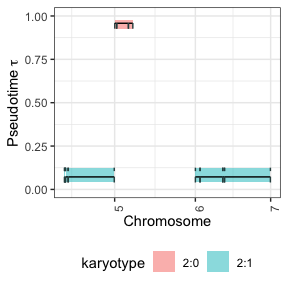

```r
tickTack::plot_timing_h(results, 2)
```

## Visualize distributions of draws from the approximate posterior

The approximate posterior distributions can be viewed using the `tickTack::plot_posterior_clocks_h` and `tickTack::plot_posterior_weights_h` functions, that internally use functions from Bayesplot.

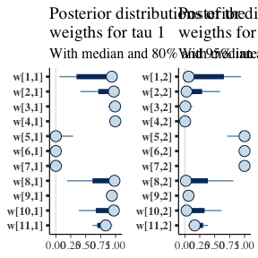

```r
posterior_clocks <- tickTack::plot_posterior_clocks_h(results, 2)
posterior_weights <- tickTack::plot_posterior_weights_h(results, 2)
```

## Visualize the behavior of the ELBO during the inference

[figure not shown]

```r
K = nrow(results_model_selection$model_selection_tibble)

p_elbo <- list()
for (i in 1:K){
  p_elbo[[i]] <- tickTack::plot_elbo_h(results$elbo_iterations[[i]]) + ggplot2::ggtitle(paste0("K = ", i))
}
p_elbo <- gridExtra::grid.arrange(grobs = p_elbo, nrow=K)  #add global title
```

```r
p_elbo
```

## Visualize all the inference results for each K

[figure not shown]

```r
plot_model_selection_inference <- list()
for (i in 1:K){
  plot_model_selection_inference[[i]] <- tickTack::plot_timing_h(results, i) + ggplot2::ggtitle(paste0("K = ", i))
}
plot_model_selection_inference <- gridExtra::grid.arrange(grobs = plot_model_selection_inference, nrow = K) #add global title
```

```r
plot_model_selection_inference
```